# Mariani (12188511) FINM HW#5

```python
#standard imports
import pandas as pd
import numpy as np
import scipy as sp
import matplotlib.pyplot as plt
import quandl
import functools
import os
import math
from datetime import datetime, timedelta
import requests
from itertools import combinations

from datetime import datetime, timedelta


my_api_key = HIDDEN
pd.set_option("max_columns", None)
pd.set_option("max_rows", None)
```

Zachary Mariani's Problem Set #5

## FX Carry Strategy

### Due May 6, 2021 at 11:00PM Chicago Time

We will start by stating a few assumptions:

1. We will always start and end our strategy in USD - as we might assume that the investor of this strategy primarily uses USD.
2. We will only use the set {THB, RON, JPY, IDR} as our possible lending and borrowing currencies. NB: although the JPY is the only developed currency and section 4.2 of the assignment mentions that "the borrow leg in mature-economy currencies such as JPY, USD, and EUR", we will not be using USD or EUR as the borrowing currencies in order to keep the trade simple and managable. As mentioned, we will report all PnL in USD.
3. We assume we have 10MM USD, in total, 2MM of which we supply and 8MM of which is borrowed to use to trade for each potential currency pair. As such, losses midstrategy do not affect the total amount of capital available to invest. Although this is potentially unrealistic as an expectation, for the purposes of this assignment it will suffice.
4. We will use FX rates from the day close on Wednesday. NB: FX markets trade 24/5 so in some sense, this is a more realistic assumption than assuming we can trade at end of day prices for US equities. However, it is still potentially unrealistic to assume we would get these exact prices, nevertheless, we are going to let this assumption hold.

### Step 1: Gathering Data

For our strategy, we will need yield curves for our five currencies of interest, and their FX rates.

Data availibility:

1. THB (2014/12 - 2021/04)
2. RON (2011/01 - 2021/04)
3. JPY (1974/09 - 2021/04)
4. IDR (2014/12 - 2021/04)
5. USD (1990/01 - 2021/04)

Given the spread of the data, we are going to filter our analysis to only the period between 2014/12 and 2021/04. Further, we will only pull data from Wednesdays within that period. If a Wednesday is missing data, we will forward fill it.

We will now get only the Wednesdays in the period of interest.

```python
#fixed start and end dates
start_date = '2014-12-01'
end_date = '2021-04-30'

#generate Wednesdays
start, end = datetime(2014, 12, 1), datetime(2021, 4, 30)
days = (start + timedelta(days=i) for i in range((end - start).days + 1))
wednesdays = [d for d in days if d.weekday() in [2] ]
wednesdays_strs = [day.strftime("%m-%d-%Y") for day in wednesdays]
```

```python
THB = quandl.get('YC/THA', start_date = start_date, end_date = end_date, api_key = my_api_key)
THB = THB.loc[THB.index.isin(wednesdays_strs)]
```

```python
RON = quandl.get('YC/ROU', start_date = start_date, end_date = end_date, api_key = my_api_key)
RON = RON.loc[RON.index.isin(wednesdays_strs)]
```

```python
JPY = quandl.get('YC/JPN', start_date = start_date, end_date = end_date, api_key = my_api_key)
JPY = JPY.loc[JPY.index.isin(wednesdays_strs)]
```

```python
IDR = quandl.get('YC/IDN', start_date = start_date, end_date = end_date, api_key = my_api_key)
IDR = IDR.loc[IDR.index.isin(wednesdays_strs)]
```

```python
USD = quandl.get('YC/USA', start_date = start_date, end_date = end_date, api_key = my_api_key)
USD = USD.loc[USD.index.isin(wednesdays_strs)]
```

Now, we will go through the data and for those currencies that do not have data for 3M, we use the closest avaiable month so that each currency has 3M, 6M, 1Y, and 5Y. Although this is not perhaps the most accurate way to do interpolate this data (consider for instance that if 3M data is missing and we fill it with 1Y data, it is likely that the 1Y data will be much higher than the 3M data), it is the method outlined in the problem set.

```python
RON['3-Month'] = RON['6-Month']
RON['1-Year'] = RON['12-Month']
JPY['6-Month'] = JPY['1-Year']
JPY['3-Month'] = JPY['1-Year']
IDR['6-Month'] = IDR['1-Year']
IDR['3-Month'] = IDR['1-Year']
```

Now, to make the datasets cleaner and faster, we will filter down to only the columns that we care about. We chose the 3 year because it is available for every dataset.

```python
of_interest = ['3-Month', '6-Month', '1-Year', '3-Year', '5-Year']
RON = RON[of_interest]
JPY = JPY[of_interest]
IDR = IDR[of_interest]
USD = USD[of_interest]
THB = THB[of_interest]
```

We have one more task, on Wednesdays where we don't have any data, we want to forward fill the data.

```python
wed_sr = np.array(wednesdays)
wed_df = pd.DataFrame(index=wed_sr)

RON = wed_df.merge(RON, left_index=True, right_index = True, how = 'outer').fillna(method = 'ffill')
JPY = wed_df.merge(JPY, left_index=True, right_index = True, how = 'outer').fillna(method = 'ffill')
IDR = wed_df.merge(IDR, left_index=True, right_index = True, how = 'outer').fillna(method = 'ffill')
USD = wed_df.merge(USD, left_index=True, right_index = True, how = 'outer').fillna(method = 'ffill')
THB = wed_df.merge(THB, left_index=True, right_index = True, how = 'outer').fillna(method = 'ffill')

#establish the rate_dict to use later
rate_dict = {'RON': RON,
            'JPY': JPY,
            'IDR': IDR,
            'USD': USD,
            'THB' : THB}
```

Now that we have finished importing the yield curve data for the countries of interest, we will now import the FX rates. We will only get pairs for the currencies as quoted in USD. We will assume that markets are perfectly efficient at these prices (ie the rate for JPY/IDR is equal to JPY/USD * USD/IDR). We have to use this assumption because no dataset on Quandl offers as exotic crosses such as RON/THB. Further, although in reality there are different bid and ask prices for the pairs, we will be using the data set "Foreign Exchange Rates" instead of "FXCM Daily FX Rates" because it offers coverage of some currencies which FXCM does not. By making this choice, we must just use the one price quoted.

```python
USD_JPY = quandl.get('CUR/JPY', start_date = start_date, end_date = end_date)
USD_JPY = USD_JPY.loc[USD_JPY.index.isin(wednesdays)]
```

```python
USD_IDR = quandl.get('CUR/IDR', start_date = start_date, end_date = end_date)
USD_IDR = USD_IDR.loc[USD_IDR.index.isin(wednesdays)]
```

```python
USD_RON = quandl.get('CUR/RON', start_date = start_date, end_date = end_date)
USD_RON = USD_RON.loc[USD_RON.index.isin(wednesdays)]
```

```python
USD_THB = quandl.get('CUR/THB', start_date = start_date, end_date = end_date)
USD_THB = USD_THB.loc[USD_THB.index.isin(wednesdays)]
```

```python
#fill any empty Wednesdays with FX data from the previous Wednesday

wed_sr = np.array(wednesdays)
wed_df = pd.DataFrame(index=wed_sr)

USD_JPY = wed_df.merge(USD_JPY, left_index=True, right_index = True, how = 'outer').fillna(method = 'ffill')
USD_IDR = wed_df.merge(USD_IDR, left_index=True, right_index = True, how = 'outer').fillna(method = 'ffill')
USD_RON = wed_df.merge(USD_RON, left_index=True, right_index = True, how = 'outer').fillna(method = 'ffill')
USD_THB = wed_df.merge(USD_THB, left_index=True, right_index = True, how = 'outer').fillna(method = 'ffill')

#establish fx_dict to use later
fx_dict = {
    'JPY' : USD_JPY,
    'IDR' : USD_IDR,
    'RON' : USD_RON,
    'THB' : USD_THB
}
```

Now that we have successfully gathered all of the data we will need. We will begin to design our simulation!

### Step 2: Designing the Algorithm

It is helpful now to review the strategy as a whole - in aggregate for week t and t+1:

Borrowing Side at t:

- We borrow 8MM USD worth of the local currency

Borrowing Side at t+1:

- We return our 8MM USD worth of the local currency plus the 3M + 50bps interest at the new exchange rate

Lending Side at t:

- We buy a bond that will pay the 5YR rate as if it were a zero-coupon bond

Lending Side at t+1:

- We sell the bond as if it were a zero-coupon bond and convert the proceeds to USD

```python
def determine_pairs_to_trade(day):
    '''
    A helper function which takes in a day (a wednesday)
    as a datetime or string object. Then, determines which
    pairs to trade, based on the condition that one currency's 5yr
    rate is more than 50bps higher than the other's.
    '''
    out_lst = []

    #we get every 5yr rate
    JPY_5yr = JPY.loc[day]['5-Year']
    IDR_5yr = IDR.loc[day]['5-Year']
    RON_5yr = RON.loc[day]['5-Year']
    THB_5yr = THB.loc[day]['5-Year']

    fiveyrs = { 'JPY' : JPY_5yr,
               'IDR' : IDR_5yr,
               'RON' : RON_5yr,
               'THB' : THB_5yr}

    #we compare each currency to every other one
    for currency, rate in fiveyrs.items():
        for currency_1, rate_1 in fiveyrs.items():
            #if its rate is greater than the other plus 50 bps then we will be
            #lending on this currency and borrowing on the other
            if rate > rate_1 + 0.50:
                out_lst.append((currency, currency_1))
    return out_lst
```

```python
def reset_current_positions():
    '''
    A helper function to return an empty current positions
    dictionary. The assignment offers that at the end of each
    week, we close all of our positions before opening new ones,
    thus, we use this dictionary.
    '''
    current_positions = {
    'JPY_lending':    0,
    'JPY_borrowing':  0,
    'IDR_lending':    0,
    'IDR_borrowing':  0,
    'RON_lending':    0,
    'RON_borrowing':  0,
    'THB_lending':    0,
    'THB_borrowing':  0
    }
    return current_positions

def reset_all_potential_pairs():
    '''
    A helper function which is similar to above. It returns an
    empty dict of all the possible pairs that we might trade.
    '''
    currencies = ['JPY', 'THB', 'IDR', 'RON']
    all_potential_pairs = []
    for c in currencies:
        for c_1 in currencies:
            if c != c_1:
                all_potential_pairs.append(c+'/'+c_1)
    (all_potential_pairs)

    all_potential_pairs_dict = {}
    for pair in all_potential_pairs:
        all_potential_pairs_dict[pair] = 0

    all_potential_pairs_dict
    return all_potential_pairs_dict
```

The cell below figures out which positions our strategy should have on each day.

```python
############## set up our positions df ################
current_positions = reset_current_positions()
positions = pd.DataFrame(current_positions, index=[0])
positions.index.name = 'Date'

############## set up our pairs df ####################
all_potential_pairs_dict = reset_all_potential_pairs()
pairs_df = pd.DataFrame(all_potential_pairs_dict, index =[0])
pairs_df.index.name = 'Date'

### loop through each day to get our position sizes ###

for day in wednesdays:

    #we reset to 0 as is outlined in the assignment
    current_positions = reset_current_positions()
    all_potential_pairs_dict = reset_all_potential_pairs()

    #use a try loop so one mistake doesn't cause the whole thing
    #to break
    try:
        #get the pairs
        pairs_to_trade = determine_pairs_to_trade(day)
        for pair in pairs_to_trade:
            lending_currency, borrowing_currency = pair

            #record that we are the pair on this day
            all_potential_pairs_dict[lending_currency + '/' + borrowing_currency] += 1

            #we calculate the total value of the currency lent
            if lending_currency != 'USD':
                currency_lent = 10000000 * fx_dict[lending_currency]['RATE'].loc[day]
            else:
                currency_lent = 10000000

            current_positions[lending_currency + '_lending'] += currency_lent

            #we assume we are borrowing 8MM USD in the borrowing currency
            if borrowing_currency != 'USD':
                currency_borrowed = 8000000 * fx_dict[borrowing_currency]['RATE'].loc[day]
            else:
                currency_borrowed = 8000000

            current_positions[borrowing_currency + '_borrowing'] += currency_borrowed

            #NB: the currency borrowed is 8MM while the currency lent is 10MM, this
            #implies that we are investing 2MM of our own capital that we don't have
            #to pay any interest on as is outlined in the assignment

        #once we have done all of our positions for this day, we store them in the positions df
        to_append = pd.DataFrame(current_positions, index = [day])
        to_append.index.name = 'Date'
        positions = positions.append(to_append)

        to_append = pd.DataFrame(all_potential_pairs_dict, index = [day])
        to_append.index.name = 'Date'
        pairs_df = pairs_df.append(to_append)

    except Exception as e:
        print(e)

#get rid of the first empty row that we just used to construct df
pairs_df = pairs_df.iloc[1:]
positions = positions.iloc[1:]
```

Now that we've generated both pairs_df and positions let's take a look

```python
pairs_df.head()
```

| Date | JPY/THB | JPY/IDR | JPY/RON | THB/JPY | THB/IDR | THB/RON | IDR/JPY | IDR/THB | IDR/RON | RON/JPY | RON/THB | RON/IDR |
| --- | --- | --- | --- | --- | --- | --- | --- | --- | --- | --- | --- | --- |
| 2014-12-03 00:00:00 | 0 | 0 | 0 | 1 | 0 | 0 | 1 | 1 | 1 | 1 | 0 | 0 |
| 2014-12-10 00:00:00 | 0 | 0 | 0 | 1 | 0 | 0 | 1 | 1 | 1 | 1 | 0 | 0 |
| 2014-12-17 00:00:00 | 0 | 0 | 0 | 1 | 0 | 0 | 1 | 1 | 1 | 1 | 0 | 0 |
| 2014-12-24 00:00:00 | 0 | 0 | 0 | 1 | 0 | 0 | 1 | 1 | 1 | 1 | 0 | 0 |
| 2014-12-31 00:00:00 | 0 | 0 | 0 | 1 | 0 | 0 | 1 | 1 | 1 | 1 | 0 | 0 |

```python
positions.head()
```

| Date | JPY_lending | JPY_borrowing | IDR_lending | IDR_borrowing | RON_lending | RON_borrowing | THB_lending | THB_borrowing |
| --- | --- | --- | --- | --- | --- | --- | --- | --- |
| 2014-12-03 00:00:00 | 0 | 2.867347e+09 | 3.693300e+11 | 0 | 35825550.0 | 28660440.0 | 328565800.0 | 262852640.0 |
| 2014-12-10 00:00:00 | 0 | 2.840424e+09 | 3.706580e+11 | 0 | 35770330.0 | 28616264.0 | 328296100.0 | 262636880.0 |
| 2014-12-17 00:00:00 | 0 | 2.843234e+09 | 3.810725e+11 | 0 | 36199200.0 | 28959360.0 | 329540200.0 | 263632160.0 |
| 2014-12-24 00:00:00 | 0 | 2.890346e+09 | 3.741630e+11 | 0 | 36613900.0 | 29291120.0 | 328855200.0 | 263084160.0 |
| 2014-12-31 00:00:00 | 0 | 2.874204e+09 | 3.725965e+11 | 0 | 36979550.0 | 29583640.0 | 328990800.0 | 263192640.0 |

Our work above gives us our positions in the currencies as borrowing or lending over the entire period as well as the pairs_df object which gives us insight into which pairs we are trading. A one in the column indicates that we are lending the first currency and borrowing the second.

### Step 3.1: Getting PnL on the Borrowing Side

We will now convert this data into useful PnL data to analyze. The first step in doing this is to calculate the total amount we had to pay out in interest on the currency we borrowed. We calculate this by multiplying the amount we borrowed by the 3M interest rate for the currency then by 1/52 and then by calculating that payment in the forward week's currency exchange rate.

```python
#make a PnL dataframe
PnL = positions
PnL = PnL[[]]
PnL['Borrow'] = 0;
```

```python
#if we were borrowing
for column in positions.columns:
    if column.split('_')[1] == 'borrowing':
        cur = column.split('_')[0]

        #the amount of money we need to pay on is 1/52 for one week, at the 3M+50bps rate
        money_lent = positions[column] * (1/52) * ((rate_dict[cur]['3-Month'] + 0.50) / 100)

        #if it's not in USD, convert it to USD at the following week's rate
        if cur != 'USD':
            money_lent = money_lent * (1/fx_dict[cur]['RATE'].shift(-1))

        PnL['Borrow'] += money_lent


#multiply by -1 to represent money paid out
PnL['Borrow'] = PnL['Borrow'] * -1
PnL['Borrow_cumsum'] = PnL['Borrow'].cumsum()
```

```python
PnL.head()
```

| Date | Borrow | Borrow_cumsum |
| --- | --- | --- |
| 2014-12-03 00:00:00 | -9294.586283 | -9294.586283 |
| 2014-12-10 00:00:00 | -9095.645888 | -18390.232171 |
| 2014-12-17 00:00:00 | -9298.875089 | -27689.107261 |
| 2014-12-24 00:00:00 | -9044.779126 | -36733.886387 |
| 2014-12-31 00:00:00 | -8970.303776 | -45704.190162 |

### Step 3.2: Calculating PnL on the Lending Side

Now, we will calculate the lending side of the trade. We assume that for all of the currencies we are lending, we are lending at their local 5YR rate, and that they collect coupons every quarter at the 5YR rate.

Given the constraints of the data sets (ie that not every data set has every year's rate), we will use the 1y, 3y, and 5y yields to discount the coupon payments.

```python
rates_for_yc = rate_dict
for key, value in rates_for_yc.items():
    rates_for_yc[key] = value[['1-Year', '3-Year', '5-Year']]
```

```python
def get_bond_values(rates_0, rates_1):
    '''
    A helper function which takes in rates_0 and rates_1
    these are series of the 1, 3, and 5yr rates at weeks
    t and t+1. We then figure out the prices of a bond
    with 5yr coupons for t_0 and t_1 (week and next week).
    From here, we find the zero-coupon bond value and then the
    change between the two.
    '''
    #to get present value of bond
    #https://www.accaglobal.com/lk/en/student/exam-support-resources/professional-exams-study-resources/p4/technical-articles/bond-valuation-yields.html

    #face_value is not important for this calculation, just a place holder
    #we calculate the change over time which is independant of face_value
    face_value = 100

    one_yr_0 = rates_0[0] / 100
    three_yr_0 = rates_0[1] / 100
    five_yr_0 = rates_0[2] / 100

    one_yr_1 = rates_1[0] / 100
    three_yr_1 = rates_1[1] / 100
    five_yr_1 = rates_1[2] / 100


    #coupons stay the same between both bonds!
    coupons = np.ones(20) * face_value * five_yr_0 / 4
    coupons[-1] += face_value

    rate_0 = np.append(np.append(np.ones(6) * one_yr_0, np.ones(8) * three_yr_0) , np.ones(6) * five_yr_0)
    rate_1 = np.append(np.append(np.ones(6) * one_yr_1, np.ones(8) * three_yr_1) , np.ones(6) * five_yr_1)

    time_0 = np.arange(0.25, 5.25, 0.25)
    time_1 = time_0 - (1/52)

    #we now discount the value of the coupons based on the times
    #and the yield curves
    pv_coupon_0 = coupons/((1+rate_0)**time_0)
    pv_bond_0 = sum(pv_coupon_0)

    pv_coupon_1 = coupons/((1+rate_1)**time_1)
    pv_bond_1 = sum(pv_coupon_1)


    #in some cases, we have negative interest rates,
    #this is to handle those instances
    if sum(coupons) >= 0:
        yld_0 = (sum(coupons)/pv_bond_0)**(1/5) - 1
        yld_1 = (sum(coupons)/pv_bond_1)**(1/(5-(1/52))) - 1
    if sum(coupons) < 0:
        yld_0 = ((-1*sum(coupons)) / pv_bond_0)**(1/5) - 1
        yld_0 = -1 * yld_0

        yld_1 = ((-1*sum(coupons)) / pv_bond_1)**(1/(5-(1/52))) - 1
        yld_1 = -1 * yld_1


    #now get the zero_coupon_bond price
    #https://www.investopedia.com/terms/z/zero-couponbond.asp
    zero_coupon_price_0 = face_value / (1+yld_0)**5
    zero_coupon_price_1 = face_value / (1+yld_1)**(5 - 1/52)

    #get the change from the zero coupon price from t=0 to t=1
    pct_change = (zero_coupon_price_1 - zero_coupon_price_0) / zero_coupon_price_0

    return pct_change
```

```python
for column in positions.columns:
    if column.split('_')[1] == 'lending':
        pct_change_lst = []
        currency = column.split('_')[0]
        yc = rates_for_yc[currency]
        borrowing_positons = positions[column]

        try:
            for date in borrowing_positons.index:
                rates_0 = yc.loc[date]
                rates_1 = yc.loc[date + timedelta(weeks=1)]

                pct_change = get_bond_values(rates_0, rates_1)
                pct_change_lst.append(pct_change)

        #this exception is to just catch the last day and make sure
        #that no earlier error stops the loop
        except Exception as e:
            print(e)
            pct_change_lst.append(None)
        PnL[currency + '_pctchange'] = pct_change_lst
```

```python
#Now, we can take a look the the PnL again just to make sure everything seems right until this point.
#We will later use this information to see how much each currency helped or hurt us.
PnL.head()
```

| Date | Borrow | Borrow_cumsum | JPY_pctchange | IDR_pctchange | RON_pctchange | THB_pctchange |
| --- | --- | --- | --- | --- | --- | --- |
| 2014-12-03 00:00:00 | -9294.586283 | -9294.586283 | -0.000383 | -0.003234 | 0.004073 | -0.000811 |
| 2014-12-10 00:00:00 | -9095.645888 | -18390.232171 | 0.001804 | -0.014701 | -0.004023 | -0.003566 |
| 2014-12-17 00:00:00 | -9298.875089 | -27689.107261 | 0.000507 | 0.001495 | 0.002759 | 0.000460 |
| 2014-12-24 00:00:00 | -9044.779126 | -36733.886387 | 0.000007 | 0.001495 | 0.000948 | 0.000460 |
| 2014-12-31 00:00:00 | -8970.303776 | -45704.190162 | 0.001002 | 0.016839 | 0.004566 | 0.011499 |

```python
#get USD PnL Values for the percent changes
for column in PnL.columns:
    if column.split('_')[-1] == 'pctchange':
        currency = column.split('_')[0]
        lending = positions[currency + '_lending']
        pct_change = PnL[column]

        #pct_change times the amount we were trading
        nominal = lending * pct_change

        #convert it back into USD
        fx_rate = 1/(fx_dict[currency]['RATE'].shift(-1))
        nominal = fx_rate * nominal

        PnL[currency + '_USDPnLweekly'] = nominal

#now aggregate the PnL into just lending
PnL['Lending'] = PnL['THB_USDPnLweekly'] + \
                 PnL['RON_USDPnLweekly'] + \
                 PnL['JPY_USDPnLweekly'] + \
                 PnL['IDR_USDPnLweekly']

#get cumsum PnL from just lending side
PnL['Lending_cumsum'] = PnL['Lending'].cumsum()
```

```python
PnL['Overall'] = PnL['Lending_cumsum'] + PnL['Borrow_cumsum']
```

### Step 4: Analysis

Let's now take a closer look into our performance.

### Step 4.1: Borrowing Costs

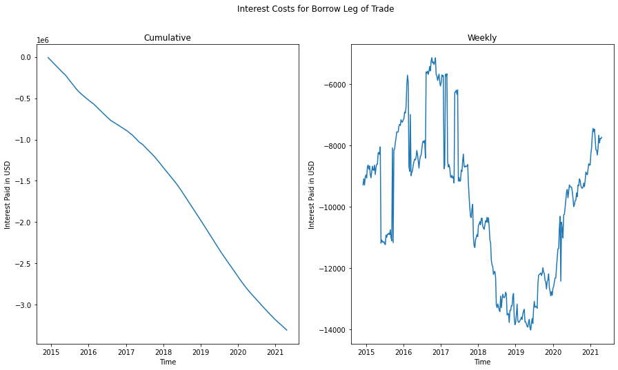

```python
fig, (ax1, ax2) = plt.subplots(1, 2, figsize = (15,8))

fig.suptitle('Interest Costs for Borrow Leg of Trade')
ax1.plot(PnL['Borrow_cumsum'])
ax1.set_title('Cumulative')
ax2.plot(PnL['Borrow'])
ax2.set_title('Weekly')

plt.ylabel('Interest Paid in USD')
plt.xlabel('Time')

ax1.set_ylabel('Interest Paid in USD')
ax1.set_xlabel('Time');
```

We can see above that although our variation in borrowing costs weekly changes by quite a lot, we have a rather smooth curve of borrowing costs downwards. This makes given the relatively tight range of the variations. We can then plot a graph of the 3M interest rates over time to see how those compare. More negative numbers mean that it costs us more to borrow.

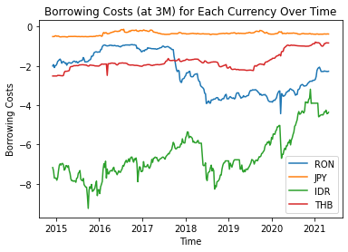

```python
plt.title("Borrowing Costs (at 3M) for Each Currency Over Time")
plt.plot((RON['3-Month'] + 0.50) * -1)
plt.plot((JPY['3-Month'] + 0.50) * -1)
plt.plot((IDR['3-Month'] + 0.50) * -1)
plt.plot((THB['3-Month'] + 0.50) * -1)
plt.legend(['RON', 'JPY', 'IDR', 'THB'])
plt.xlabel('Time')
plt.ylabel('Borrowing Costs');
```

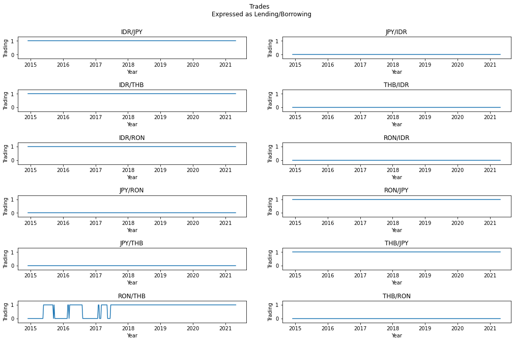

```python
fig, axs = plt.subplots(6, 2, figsize = (15,10))
fig.tight_layout(pad=4.0, rect=[0,0.03,1,0.95])

axs[0,0].set_title('IDR/JPY')
axs[0,1].set_title('JPY/IDR')
axs[0,0].plot(pairs_df['IDR/JPY'])
axs[0,1].plot(pairs_df['JPY/IDR'])

axs[1,0].set_title('IDR/THB')
axs[1,1].set_title('THB/IDR')
axs[1,0].plot(pairs_df['IDR/THB'])
axs[1,1].plot(pairs_df['THB/IDR'])

axs[2,0].set_title('IDR/RON')
axs[2,1].set_title('RON/IDR')
axs[2,0].plot(pairs_df['IDR/RON'])
axs[2,1].plot(pairs_df['RON/IDR'])

axs[3,0].set_title('JPY/RON')
axs[3,1].set_title('RON/JPY')
axs[3,0].plot(pairs_df['JPY/RON'])
axs[3,1].plot(pairs_df['RON/JPY'])

axs[4,0].set_title('JPY/THB')
axs[4,1].set_title('THB/JPY')
axs[4,0].plot(pairs_df['JPY/THB'])
axs[4,1].plot(pairs_df['THB/JPY'])

axs[5,0].set_title('RON/THB')
axs[5,1].set_title('THB/RON')
axs[5,0].plot(pairs_df['RON/THB'])
axs[5,1].plot(pairs_df['THB/RON'])

for ob in axs:
    for ax in ob:
        ax.set_ylabel('Trading')
        ax.set_xlabel('Year')
        ax.set_ylim((-0.3, 1.3))

fig.suptitle('Trades \n Expressed as Lending/Borrowing');
```

NB: a 1 means that we are actively trading, 0 means we are not trading.

Further, we can look at the distribution of our borrowing costs to see something interesting below. We have that the skew is very low and that the kurtosis is also negative just about one. This tells us that the tail of the distribution is longer towards the right-hand side of the curve (i.e. lower costs) and kurtosis being low tells us that the data has a lack of outliers and is light-tailed. I suppose that this is good for us because we know that we have relatively the same costs we sometimes the costs shifting a bit lower than average. This makes sense because over the period we saw moments where the costs moved more sharply down and take longer to go back up. Economically, (potentially) this means that when central banks raise their rates (at least for these currencies) they cut them slowly and raise them more quickly, otherwise, it implies that rates jump faster than they fall. This is an interesting finding and potentially rather counterintuitive given that at least in equities, things tend to rise slowly and then fall quickly. I suppose that inflationary expectations, a factor that influences interest rates, might have the fear mentality that falling equities share. These expectations might cause central banks and markets to raise rates quickly.

```
The Skew is:  0.015352139451814255
The Kurtosis is:  -0.9231344735714737
```

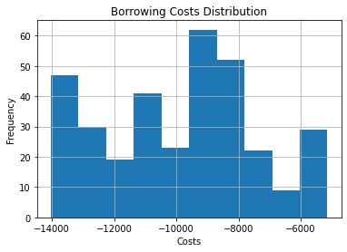

```python
PnL.hist('Borrow')
plt.title("Borrowing Costs Distribution")
plt.ylabel('Frequency')
plt.xlabel('Costs')
print('The Skew is: ', PnL['Borrow'].skew())
print('The Kurtosis is: ', PnL['Borrow'].kurt())
```

Now, we will take a moment to analyze our lending PnL. We don't have the best news here, but we can see from the graph that borrowing costs are quite predictable. We have that skew is very close to 0 which is good for us overall - means that our returns are relatively normally distributed with the tail slightly longer on the right-hand side and the bulk of returns slightly on the left-hand side. We also have that kurtosis is very low which is good for us because it implies that our borrowing costs have light tails and very few outliers. All of this makes sense given that 3M interest rates do not change all that much from one week to another and in aggregate over the time period we've looked at. We now move to the lending PnL.

### 4.2 Lending

```
The Skew is:  -2.723258122542597
The Kurtosis is:  25.716924659956735
```

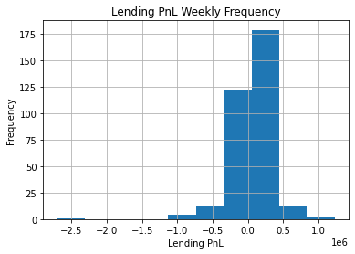

```python
PnL['Lending'].hist()
plt.title('Lending PnL Weekly Frequency')
plt.xlabel('Lending PnL')
plt.ylabel('Frequency')
print('The Skew is: ', PnL['Lending'].skew())
print('The Kurtosis is: ', PnL['Lending'].kurt())
```

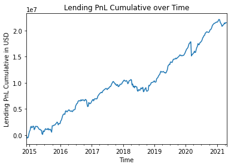

```python
PnL['Lending_cumsum'].plot()
plt.title('Lending PnL Cumulative over Time')
plt.ylabel('Lending PnL Cumulative in USD')
plt.xlabel('Time');
```

We also see, quite remarkably, a very strong steady increase here. Our lending PnL is about 3 with a much higher kurtosis. This implies that we have much wider outliers than in our borrowing side, which of course makes sense. 5yr rates move a lot more than 3m rates which would affect our performance on this side. The negative skew means that more of our weekly lending PnL is clustered on the right-hand side with a wider tail on the left. This is overall good news.

### 4.3 Overall PnL

We will now compare this to our weekly PnL. We have very similar statistics as above in the lending side, we can therefore see that the majority of our performance is coming from the lending leg and not the costs of the borrowing leg. Skew and Kurtosis overall are very similar to the skew and kurtosis for just the lending leg of the trade - this makes sense given that the 5yr rates move much more than the 3m rates and that we are only borrowing 80% of our capital and then lending 100%.

```
The Skew is:  -2.7270008375878554
The Kurtosis is:  25.766387068849866
```

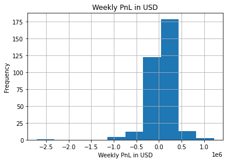

```python
weekly = PnL['Borrow'] + PnL['Lending']
weekly.hist()
plt.title("Weekly PnL in USD")
plt.xlabel('Weekly PnL in USD')
plt.ylabel('Frequency');
print('The Skew is: ', weekly.skew())
print('The Kurtosis is: ', weekly.kurt())
```

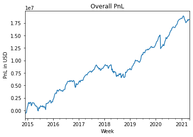

```python
PnL['Overall'].plot()
plt.title('Overall PnL')
plt.ylabel('PnL in USD')
plt.xlabel('Week');
```

### 4.4 Portfolio Returns

Let's assume, although rather unrealistically, that since we ever trade only 6 pairs and that we at most need 2MM USD per pair (8MM is borrowed) that our starting capital is thus 12MM USD. We will use this to calculate our portfolio's returns.

```python
portfolio_value = PnL['Overall'] + 12000000

#to look at returns one week into the next
PnL['1-Returns'] = portfolio_value.pct_change(1)

#to look at returns from one year ago at each point
PnL['52-Returns'] = portfolio_value.pct_change(52)
```

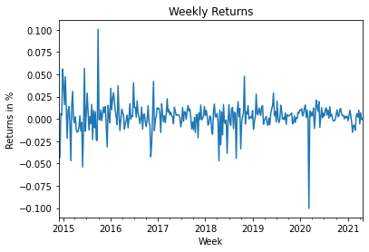

```python
PnL['1-Returns'].plot()
plt.title('Weekly Returns')
plt.xlabel('Week')
plt.ylabel('Returns in %');
```

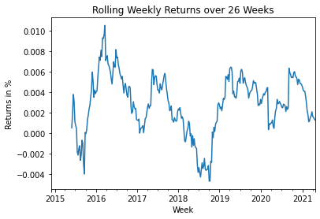

```python
rolling = PnL.rolling(26).mean()['1-Returns']
rolling.plot()
plt.title("Rolling Weekly Returns over 26 Weeks")
plt.xlabel("Week")
plt.ylabel('Returns in %');
```

```
The Skew is:  -0.3042078928245342
The Kurtosis is:  10.991267492735576
```

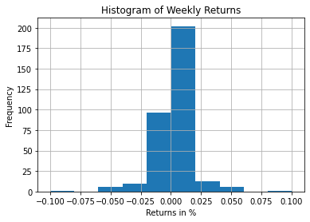

```python
PnL['1-Returns'].hist()
plt.title('Histogram of Weekly Returns')
plt.xlabel('Returns in %')
plt.ylabel('Frequency');
print('The Skew is: ', PnL['1-Returns'].skew())
print('The Kurtosis is: ', PnL['1-Returns'].kurt())
```

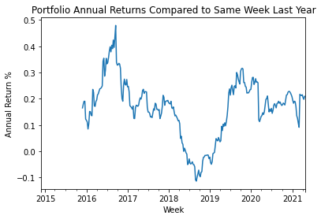

```python
PnL['52-Returns'].plot()
plt.title('Portfolio Annual Returns Compared to Same Week Last Year')
plt.xlabel('Week')
plt.ylabel('Annual Return %');
```

```
The Skew is:  -0.37983613515418796
The Kurtosis is:  0.20092022922256536
```

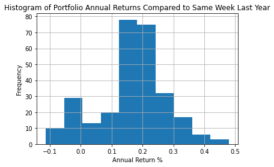

```python
PnL['52-Returns'].hist()
plt.title('Histogram of Portfolio Annual Returns Compared to Same Week Last Year')
plt.ylabel('Frequency')
plt.xlabel('Annual Return %');
print('The Skew is: ', PnL['52-Returns'].skew())
print('The Kurtosis is: ', PnL['52-Returns'].kurt())
```

A couple of thoughts on portfolio returns: We see that our skew of weekly returns was -0.3 and kurtosis was about 11 while the skew of annual returns was about -0.4 with kurtosis of 0.20. This makes a good deal of sense given that usually, returns on a weekly basis will have a much wider range than returns on an annual basis. We only had one major drawdown in in weekly performance in 2020. If we look at the appendix section (Market Conditions), we see that many currencies experienced wide changes in their 5 year rates as well as their FX rates, this uncertainty in the markets caused our portfolio to move sharply against us.

The kurtosis for the annual returns being very low is a great sign that we have few outliers, the kurtosis for the weekly returns being so high is not great but to be expected. There was only one period of prolonged drawdown from 2018 into 2019, and even so, the moves were not very bad.

A couple of concluding ideas:

1. This strategy showed remarkably good performance, in essence, a carry trade is an insurance policy - we're picking up pennies in front of a steamroller. It seems that perhaps, we might have missed the worst moves although as we can see in market conditions, there were a variety of times when our portfolio drawback was correlated with market moves in FX rates or interest rates.
2. One factor which definitely helped our stellar performance was the high leverage we were able to access. Assuming that we are a large enough fund, it is not unreasonable to think we could access such capital.
3. We completely ignored transaction costs. Given that the strategy assumes that we rebalance every week by selling and buying everything again, transaction costs would have definitely hurt our performance. However, in practice, since we did not really change the positions we were taking, it is possible that we could have keep transaction costs extremely low.
4. The window we tested on, compared to the frequency of geopolitical or other events that affect FX markets and interest rate markets was rather small. We were constrained due to the data, however, if we tested this strategy over a different or larger window, it seems likely that our results could be very different.
5. It doesn't seem like there was a regime change at all during our testing window. Our performance was much more varied earlier on, weekly returns much more spread out, however, as time went on, for the most part, our returns became slightly more stable. If there were a regime change in the market, we might expect to see the market move or trade differently i.e. the variance of the weekly returns would move a lot or the average weekly returns would converge around 0 if many people entered. If you look at the rolling 26 week mean of weekly returns, we see that it continues to vary which implies that it is unlikely that the market players meaningfully changed during the period.

### 5 Appendix: Market Conditions

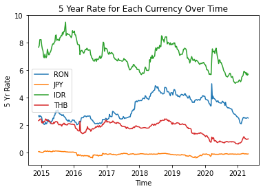

```python
plt.title("5 Year Rate for Each Currency Over Time")
plt.plot(RON['5-Year'])
plt.plot(JPY['5-Year'])
plt.plot(IDR['5-Year'])
plt.plot(THB['5-Year'])
plt.legend(['RON', 'JPY', 'IDR', 'THB'])
plt.xlabel('Time')
plt.ylabel('5 Yr Rate');
```

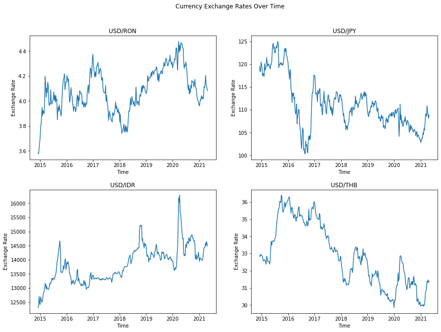

```python
fig, axs = plt.subplots(2, 2, figsize = (13,10))
fig.tight_layout(pad=4.0, rect=[0,0.03,1,0.95])
axs[0,0].plot(USD_RON['RATE'])
axs[0,0].set_title('USD/RON')

axs[0,1].plot(USD_JPY['RATE'])
axs[0,1].set_title('USD/JPY')

axs[1,0].plot(USD_IDR['RATE'])
axs[1,0].set_title('USD/IDR')

axs[1,1].plot(USD_THB['RATE'])
axs[1,1].set_title('USD/THB');

fig.suptitle('Currency Exchange Rates Over Time');
for row in axs:
    for ax in row:
        ax.set_xlabel('Time')
        ax.set_ylabel('Exchange Rate')
```